# Mustafa Tilkat Week 5 - Diamonds Price Prediction

## Diamonds Price Prediction

First of all, we need to call our libraries.

```r
library(data.table)
library(ggplot2)
library(ggthemes)
library(tidyverse)
library(highcharter)
library(plotly)
library(ggplot2)
library(xgboost)
library(randomForest)
library(caret)
library(rpart)
library(rpart.plot)
library(rattle)
library(dplyr)
```

Train and Test data sets are preparing.

```r
set.seed(555)
set.seed(555)

diamonds_test2 <- diamonds %>% mutate(diamond_id = row_number()) %>%
  group_by(cut, color, clarity) %>% sample_frac(0.2) %>% ungroup()

diamonds_train2 <- anti_join(diamonds %>% mutate(diamond_id = row_number()),
                            diamonds_test2, by = "diamond_id")

diamonds_train2<-data.table(diamonds_train2)
diamonds_test2<-data.table(diamonds_test2)
```

You can see the summry of train and test data sets.

```r
summary(diamonds_train2)
```

```
##      carat               cut        color       clarity
##  Min.   :0.2000   Fair     : 1285   D:5416   SI1    :10449
##  1st Qu.:0.4000   Good     : 3923   E:7835   VS2    : 9806
##  Median :0.7000   Very Good: 9662   F:7629   SI2    : 7354
##  Mean   :0.7977   Premium  :11036   G:9037   VS1    : 6538
##  3rd Qu.:1.0400   Ideal    :17237   H:6646   VVS2   : 4052
##  Max.   :5.0100                     I:4336   VVS1   : 2923
##                                     J:2244   (Other): 2021
##      depth           table           price               x
##  Min.   :43.00   Min.   :43.00   Min.   :  326.0   Min.   : 0.00
##  1st Qu.:61.00   1st Qu.:56.00   1st Qu.:  947.5   1st Qu.: 4.71
##  Median :61.80   Median :57.00   Median : 2398.0   Median : 5.70
##  Mean   :61.75   Mean   :57.46   Mean   : 3933.1   Mean   : 5.73
##  3rd Qu.:62.50   3rd Qu.:59.00   3rd Qu.: 5325.0   3rd Qu.: 6.54
##  Max.   :79.00   Max.   :95.00   Max.   :18823.0   Max.   :10.74
##
##        y                z            diamond_id
##  Min.   : 0.000   Min.   : 0.000   Min.   :    1
##  1st Qu.: 4.720   1st Qu.: 2.910   1st Qu.:13457
##  Median : 5.710   Median : 3.520   Median :26997
##  Mean   : 5.734   Mean   : 3.538   Mean   :26955
##  3rd Qu.: 6.540   3rd Qu.: 4.040   3rd Qu.:40415
##  Max.   :58.900   Max.   :31.800   Max.   :53940
##
```

```r
summary(diamonds_test2)
```

```
##      carat               cut       color       clarity         depth
##  Min.   :0.2000   Fair     : 325   D:1359   SI1    :2616   Min.   :43.00
##  1st Qu.:0.4000   Good     : 983   E:1962   VS2    :2452   1st Qu.:61.00
##  Median :0.7000   Very Good:2420   F:1913   SI2    :1840   Median :61.80
##  Mean   :0.7989   Premium  :2755   G:2255   VS1    :1633   Mean   :61.75
##  3rd Qu.:1.0400   Ideal    :4314   H:1658   VVS2   :1014   3rd Qu.:62.50
##  Max.   :4.1300                    I:1086   VVS1   : 732   Max.   :73.60
##                                    J: 564   (Other): 510
##      table           price             x                y
##  Min.   :49.00   Min.   :  327   Min.   : 3.810   Min.   :3.780
##  1st Qu.:56.00   1st Qu.:  956   1st Qu.: 4.720   1st Qu.:4.730
##  Median :57.00   Median : 2434   Median : 5.700   Median :5.720
##  Mean   :57.46   Mean   : 3932   Mean   : 5.734   Mean   :5.736
##  3rd Qu.:59.00   3rd Qu.: 5324   3rd Qu.: 6.540   3rd Qu.:6.540
##  Max.   :69.00   Max.   :18818   Max.   :10.010   Max.   :9.940
##
##        z           diamond_id
##  Min.   :2.240   Min.   :    3
##  1st Qu.:2.910   1st Qu.:13648
##  Median :3.530   Median :26870
##  Mean   :3.541   Mean   :27033
##  3rd Qu.:4.030   3rd Qu.:40627
##  Max.   :6.430   Max.   :53937
##
```

As you see there is no NA and some of the variables are numeric and some of them are categoric.

```r
diamonds_train2[,length(diamond_id)]
```

```
## [1] 43143
```

```r
diamonds_train2[,length(unique(diamond_id))]
```

```
## [1] 43143
```

When we check the id’s there is no problem about uniqness.

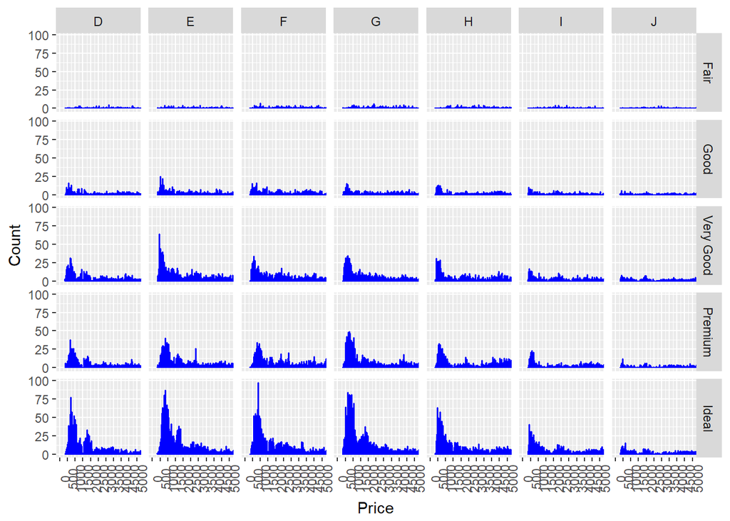

```r
ggplot(diamonds_train2, aes(x = price)) +
  geom_histogram(color = "blue", fill = "Blue", binwidth = 25) +
  scale_x_continuous(breaks = seq(0, 5000, 500)) +
  theme(axis.text.x = element_text(angle = 90)) +
  coord_cartesian(c(0,5000)) +
  facet_grid(cut~color) +
  xlab("Price") + ylab("Count")
```

In this graph we can see that Ideal cut diamonds is the the most seen data point at each colurs.

```r
diamonds_train2[x<=0 & y<=0 & z<=0,]
```

```
##    carat       cut color clarity depth table price x y z diamond_id
## 1:  1.00 Very Good     H     VS2  63.3    53  5139 0 0 0      11964
## 2:  1.14      Fair     G     VS1  57.5    67  6381 0 0 0      15952
## 3:  1.56     Ideal     G     VS2  62.2    54 12800 0 0 0      24521
## 4:  1.20   Premium     D    VVS1  62.1    59 15686 0 0 0      26244
## 5:  2.25   Premium     H     SI2  62.8    59 18034 0 0 0      27430
## 6:  0.71      Good     F     SI2  64.1    60  2130 0 0 0      49557
## 7:  0.71      Good     F     SI2  64.1    60  2130 0 0 0      49558
```

There are some diamonds which have x,y,z values are zero. It should be better to put them out.

```r
diamonds_train2<-diamonds_train2[x>0 | y>0 | z>0,]
```

```r
summary(diamonds$price)
```

```
##    Min. 1st Qu.  Median    Mean 3rd Qu.    Max.
##     326     950    2401    3933    5324   18823
```

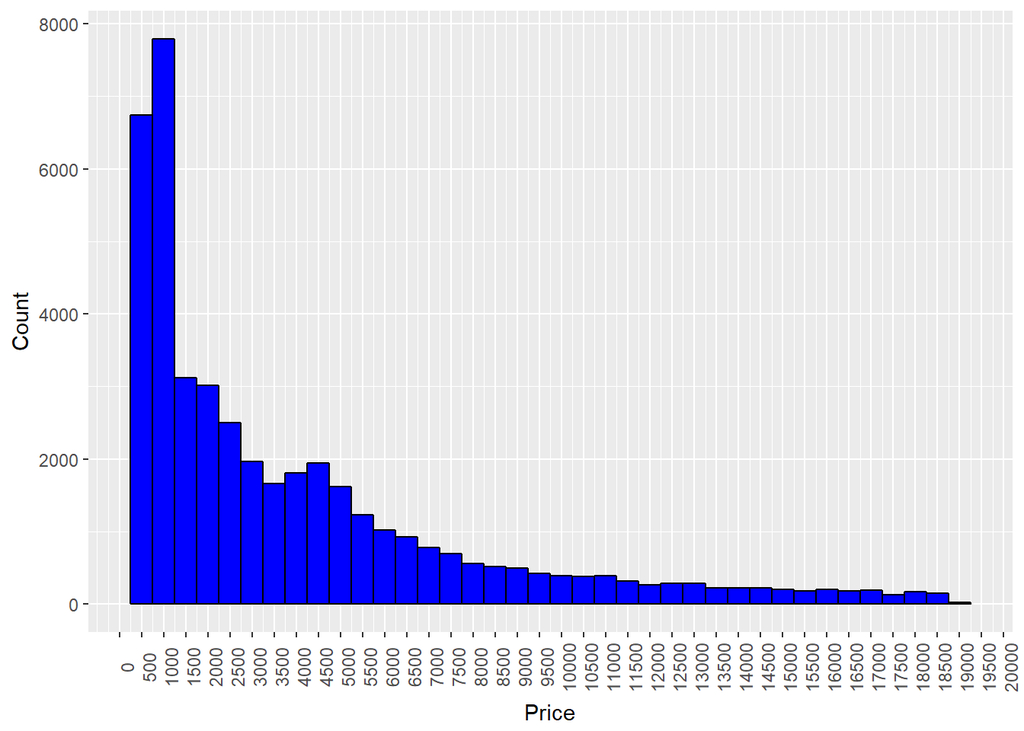

```r
ggplot(diamonds_train2, aes(x = price)) +
  geom_histogram(color = "black", fill = "Blue", binwidth = 500) +
  scale_x_continuous(breaks = seq(0, 20000, 500)) +
  theme(axis.text.x = element_text(angle = 90)) +
  xlab("Price") + ylab("Count")
```

when we check the price we can say that range is quite high so we should take the log of price.

```r
diamonds_train2[,cut1:=ifelse(cut=="Fair",1,ifelse(cut=="Good",2,ifelse(cut=="Very Good",3,ifelse(cut=="Premium",4,5))))]
diamonds_train2[,color1:=ifelse(color=="D",1,ifelse(color=="E",2,ifelse(color=="F",3,ifelse(color=="G",4,ifelse(color=="H",5,ifelse(color=="I",6,7))))))]
diamonds_train2[,clarity1:=ifelse(clarity=="I1",1,ifelse(clarity=="SI2",2,ifelse(clarity=="SI1",3,ifelse(clarity=="VS2",4,ifelse(clarity=="VS1",5,ifelse(clarity=="VVS2",6,ifelse(clarity=="VVS1",7,8)))))))]

diamonds_test2[,cut1:=ifelse(cut=="Fair",1,ifelse(cut=="Good",2,ifelse(cut=="Very Good",3,ifelse(cut=="Premium",4,5))))]
diamonds_test2[,color1:=ifelse(color=="D",1,ifelse(color=="E",2,ifelse(color=="F",3,ifelse(color=="G",4,ifelse(color=="H",5,ifelse(color=="I",6,7))))))]
diamonds_test2[,clarity1:=ifelse(clarity=="I1",1,ifelse(clarity=="SI2",2,ifelse(clarity=="SI1",3,ifelse(clarity=="VS2",4,ifelse(clarity=="VS1",5,ifelse(clarity=="VVS2",6,ifelse(clarity=="VVS1",7,8)))))))]
```

Also for modelling in train and test data set some of the variables turn it to another variable for example D is the worst color category and we will say it 1 as numeric after this process we will change the type of their class from numeric to factor.

```r
diamonds_train2[, carat_log:=log(carat),.(diamond_id)]
diamonds_test2[, carat_log:=log(carat),.(diamond_id)]

diamonds_train<-diamonds_train2[,list(carat_log,cut1,color1,clarity1,depth,x,y,z,price,diamond_id)]
diamonds_test<-diamonds_test2[,list(carat_log,cut1,color1,clarity1,depth,x,y,z,price,diamond_id)]

diamonds_train$cut1<-as.factor(diamonds_train$cut1)
diamonds_train$color1<-as.factor(diamonds_train$color1)
diamonds_train$clarity1<-as.factor(diamonds_train$clarity1)

diamonds_test$cut1<-as.factor(diamonds_test$cut1)
diamonds_test$color1<-as.factor(diamonds_test$color1)
diamonds_test$clarity1<-as.factor(diamonds_test$clarity1)
```

Carat is also an important variable and after looking its summary the logarithmic version of this variable take into consider.

```r
diamonds_train<-diamonds_train[color1==4  & clarity1==8 & cut1==5,]
diamonds_test<-diamonds_test[color1==4 & clarity1==8 & cut1==5,]
```

Clustering can give better results in tree models.But clustering was not done in this study so a samll data set was selected in existing categorical variables.

Performance measurement fuction is at below. ( Root mean square percentage error)

```r
RMPSE<- function(preds, dtrain) {
  labels <- getinfo(dtrain, "label")
  elab<-exp(as.numeric(labels))-1
  epreds<-exp(as.numeric(preds))-1
  err <- sqrt(mean((epreds/elab-1)^2))
  return(list(metric = "RMPSE", value = err))
}
```

```r
nrow(diamonds_train)
```

```
## [1] 393
```

```r
h<-sample(nrow(diamonds_train),10)
```

Crating the gbm matrix. Added 1 to sales because of log(0) goes inf

```r
dval<-xgb.DMatrix(data=data.matrix(diamonds_train[h,]),label=log(diamonds_train$price+1)[h])
dtrain<-xgb.DMatrix(data=data.matrix(diamonds_train[-h,]),label=log(diamonds_train$price+1)[-h])
watchlist<-list(val=dval,trainset=dtrain)
```

Setting the parameters

```r
param <- list(  objective           = "reg:linear",
                booster = "gbtree",
                eta                 = 0.45, # 0.40, #0.3, #0.2, #0.1, changed from 0.45
                max_depth           = 15,
                subsample           = 0.8,
                colsample_bytree    = 0.8

)
```

Finding the best seed number for maximum accuracy

```r
selectseed<-function(a,b){

  bestseed2 = data.table(s = 201, x = 1.1, y = 1.1)

  for (s in a:b){

    set.seed(s)
    set.seed(s)

    xgbmodel <- xgb.train(   params         = param,
                             data                = dtrain,
                             nrounds             = 30, #10, #20, #30, #100, # changed from 30
                             verbose             = 0,
                             early.stop.round    = 25,
                             watchlist           = watchlist,
                             maximize            = FALSE,
                             feval=RMPSE
    )
    testset<-data.frame(diamonds_test)

    feature.names <- names(diamonds_test)[-c(9,10)]

    forecasts <- exp(predict(xgbmodel, data.matrix(testset[,feature.names]))) -1

    forecasts<-data.table(forecasts)

    submission <- data.frame(diamond_id=testset$diamond_id, price=forecasts)

    submission<-data.table(submission)
    testset<-data.table(testset)

    setkey(submission,diamond_id)
    setkey(testset,diamond_id)

    final<-testset[submission]

    final[,Err:=abs(forecasts-price)/price]
    final2<-final[,list(sum(price),sum(abs(forecasts-price)),sum(price)),.(diamond_id)]

    setnames(final2,"V1","TWS")
    setnames(final2,"V2","TE")
    setnames(final2,"V3","TP")

    x<-final2[,sum(TE)/sum(TWS)]
    y<-final[,mean(Err)]

    bestseed<-data.table(s,x,y)
    bestseed2<-rbind(bestseed,bestseed2)

  }

  seed<-head(bestseed2[order(x)],1)[]$s
  return(seed)
}
```

Setting the best seed the number between a to b

```r
a=1
b=50
seed=selectseed(a,b)
set.seed(seed)
set.seed(seed)
```

Training the xgboost model

```r
xgbmodel <- xgb.train(   params              = param,
                         data                = dtrain,
                         nrounds             = 30, #10, #20, #30, #100, # changed from 30
                         verbose             = 1,
                         early.stop.round    = 25,
                         watchlist           = watchlist,
                         maximize            = FALSE,
                         feval=RMPSE
)
```

```
## Multiple eval metrics are present. Will use trainset_RMPSE for early stopping.
## Will train until trainset_RMPSE hasn't improved in 25 rounds.
##
```

Setting the feature names in test dataset

```r
testset<-data.frame(diamonds_test)
feature.names <- names(testset)[-c(9,10)]
```

Generating the forecast with predict function and the exp function converts the values log to normal

```r
forecasts <- exp(predict(xgbmodel, data.matrix(testset[,feature.names]))) -1
forecasts<-data.table(forecasts)
```

Crating the final table which obtains forecasts and actual values

```r
submission <- data.frame(diamond_id=testset$diamond_id, price=forecasts)

submission<-data.table(submission)
testset<-data.table(testset)

setkey(submission,diamond_id)
setkey(testset,diamond_id)

final<-testset[submission]
```

Measuring the performance

```r
final[,Err:=abs(forecasts-price)/price]
final2<-final[,list(sum(price),sum(abs(forecasts-price)),sum(forecasts)),.(diamond_id)]

setnames(final2,"V1","TWS") #Total Weekly Sales
setnames(final2,"V2","TE")  #Total Errors
setnames(final2,"V3","TF")  #Total Forecasts

final2[,sum(TE)/sum(TWS)]
```

```
## [1] 0.1574091
```

```r
final[,mean(Err)]
```

```
## [1] 0.1299294
```

We can see that the average error is only %15 and it sounds good. Lets look it on a graph.

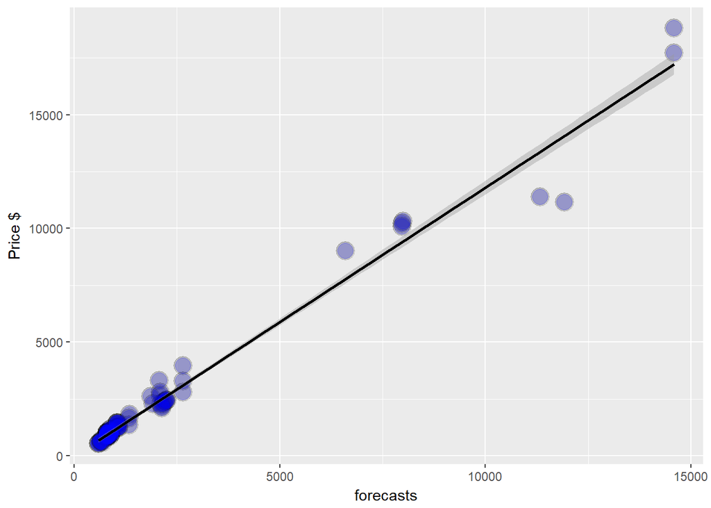

```r
g=ggplot(final,aes(x=forecasts,y=price),)
g=g+xlab("forecasts")
g=g+ylab("Price $")
g=g+geom_point(size=6,colour="black",alpha=0.2)
g=g+geom_point(size=5,colour="blue",alpha=0.2)
g=g+geom_smooth(method="lm",colour="black")
g
```

As it can seen on graph high price point is the weak side of our model. Maybe parameter optimization cn help or adding new variable helps reaching better results.

```r
model <- xgb.dump(xgbmodel, with.stats = T)
```

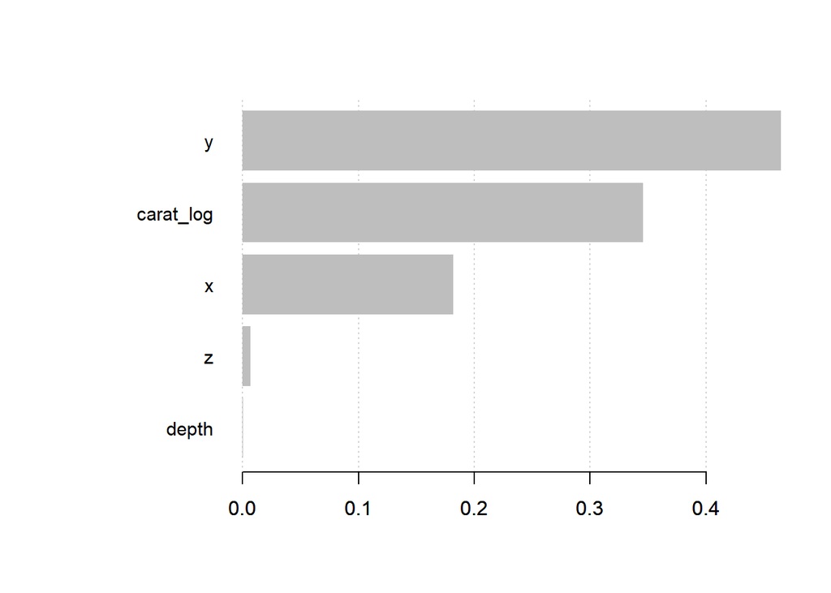

```r
names <- dimnames(data.matrix(testset[,-c(9,10)]))[[2]]
importance_matrix <- xgb.importance(names, model = xgbmodel)
xgb.plot.importance(importance_matrix[1:5,])
```